# Lab 1 Group Project

Emmanuel Robi, Andrew Baker, Jamie Marken, Alberto Melendez, James Lyou

January 22, 2019

# Part 1.1

Based off the âAll China Data Centerâ our assumption why some cities like Beijing and Shanghai are included in this list of provinces is due to population size. We noted many provinces with a population with 2,000,000 persons or more were considered âSuper Large-sized citiesâ. Looking in the database there is missing data on some provinces and cities which may be due to the fact that there just wasnât data collected in the region or data collected was incorrectly. Much of the data comes from the year 2000. On an atlas the part of the Peopleâs Republic of China that may people donât really focus on is Western China. People are more focused on the eastern parts of China.

# Part 1.2

It would be more reliable to use older data than current data because of how unreliable Chinaâs information is. There was a lot of faking of data in the 90â. The data between 2000-2011 is considered the most accurate give or take. According to Bloomberg, âIf the official data lacks credibility, alternative narrativesâlike an economy on the verge of a hard landingâcan take hold,â says Tom Orlik. To validate this, Economist writes âAnd Chinaâs national GDP figure is laughably out of line with the sum of its provincial GDP figures. The various levels of government cannot keep their statistical stories straight.â The article articulates on how China has data that doesnât correspond with other information discrediting the information. Since China has a difficult time concluding there true worth, it has gained a reputation to produce false information. Sara from Forbes writes, âBut after years of producing growth even in the darkest of circumstances, China has gained a reputation for possibly overestimating its growth rate.â This further recognizes how the more time goes by, the more unreliable Chinaâs data actually is.

### Specific years to look out for in our data

Because of the reasons listed above it is importent to talk about which years may not be as reliable as others in our data. There might be points that we have missed, but the following points are improtant to note while looking at our plots.

1. **1991-1994**: “Beijing fully adopted the international System of National Accounting (SNA) in 1995, which is designed to measure indicators of relevance to a market economy”. Following this, it was revealed that that industrial data had serious problems with realiability.
2. **1983-2011**: Statistical reforms are prevalent through this timeline meaning that definitions of output, output, GDP, etc. change.
3. **1959-1962**: Called “The Great Leap Forward”, China faced extreme declines in argiculure and local officials manipulated their data to reflect this more postively.
4. **1980’s**: (already listed but for different reasons and slightly different range). China suffered large inflation and unemployment, but reported growth when some scholars believe it contracted in 1989.
5. **1998**: Asian Financial Crisis occurs. China still reports growth despite significant decline in certain industries (mostly energy consumption and airline travel). Also when the NBS revised historical data in 2005, 1998 was not given any revision.

# Part1 Citations

https://www.bloomberg.com/news/articles/2018-04-19/china-s-economic-stats-have-a-credibility-problem

https://www.economist.com/finance-and-economics/2018/07/07/chinas-statistics-are-bad-many-criticisms-of-them-are-worse

https://www.forbes.com/sites/sarahsu/2017/01/23/chinas-gdp-numbers-can-we-trust-the-data/

U.S.-China Economic and Security Review Commission Staff Research Project(2013) (included in repo)

# Part 2.2

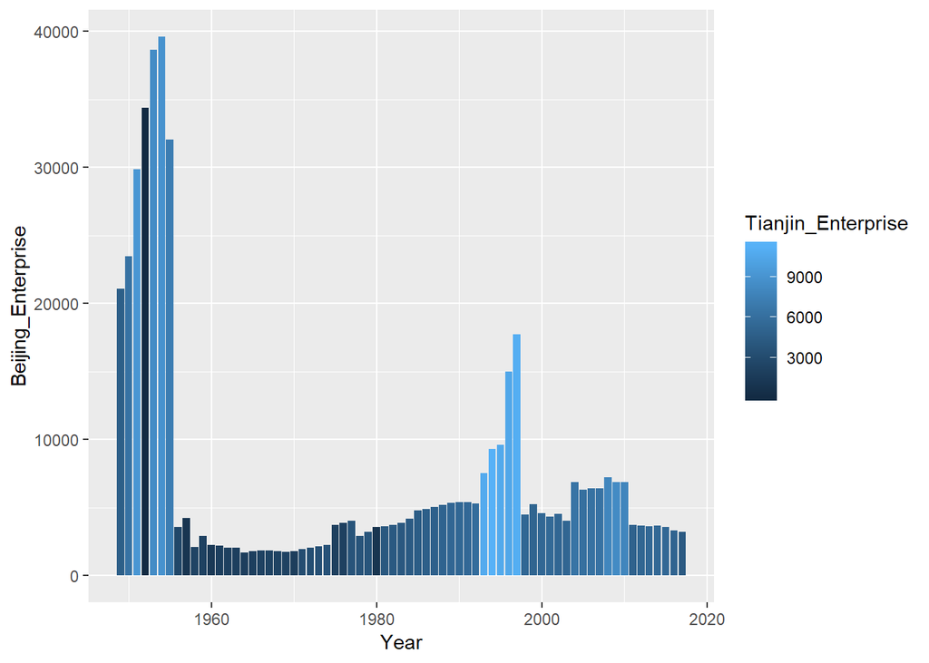

```r
###Create plot that is imported from the Year and Beijing_Enterprise columns
p <-ggplot(data = Data, aes(Year, Beijing_Enterprise))

###Imports third colum from the Tianjin_Enterprise column changing the bar to a different shade of blue
p +geom_bar(stat="identity", aes(fill =Tianjin_Enterprise))
```

# Part 2.1/2.2

### Summary

Output is lower in every graph, but enterprise goes up as well. possible they are the same enterprises.

Shanghai and Beijing both start off the economic growth in the 1940’s and the rest follow.

# Part 3.1

```
##    Year Shandong_Output Fujian_Output Output_Ratio
## 1  1950           13.07          2.45     5.334694
## 2  1951           16.27          3.20     5.084375
## 3  1952           20.08          4.20     4.780952
## 4  1953           25.41          5.43     4.679558
## 5  1954           29.35          6.12     4.795752
## 6  1955           30.10          6.35     4.740157
## 7  1956           39.64          7.32     5.415301
## 8  1957           43.31          8.57     5.053676
## 9  1958           69.57         12.94     5.376352
## 10 1959           92.98         19.56     4.753579
## 11 1960           97.91         25.01     3.914834
## 12 1961           55.04         13.77     3.997095
## 13 1962           45.70         11.23     4.069457
## 14 1963           49.10         11.33     4.333628
```

[output cut: 49 more lines]

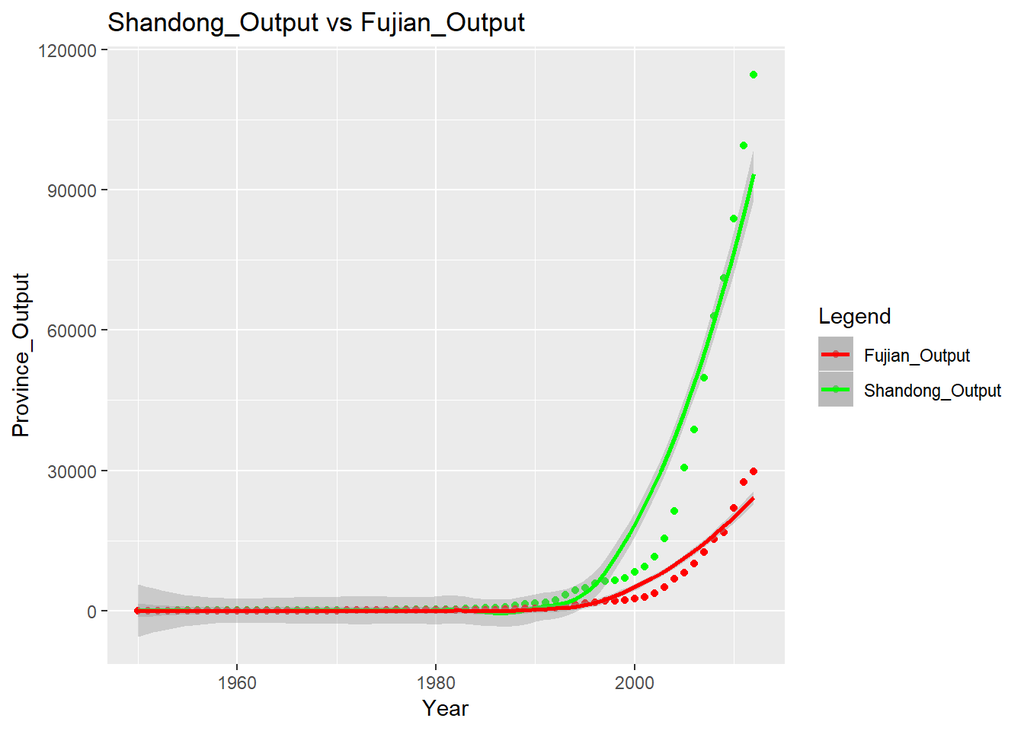

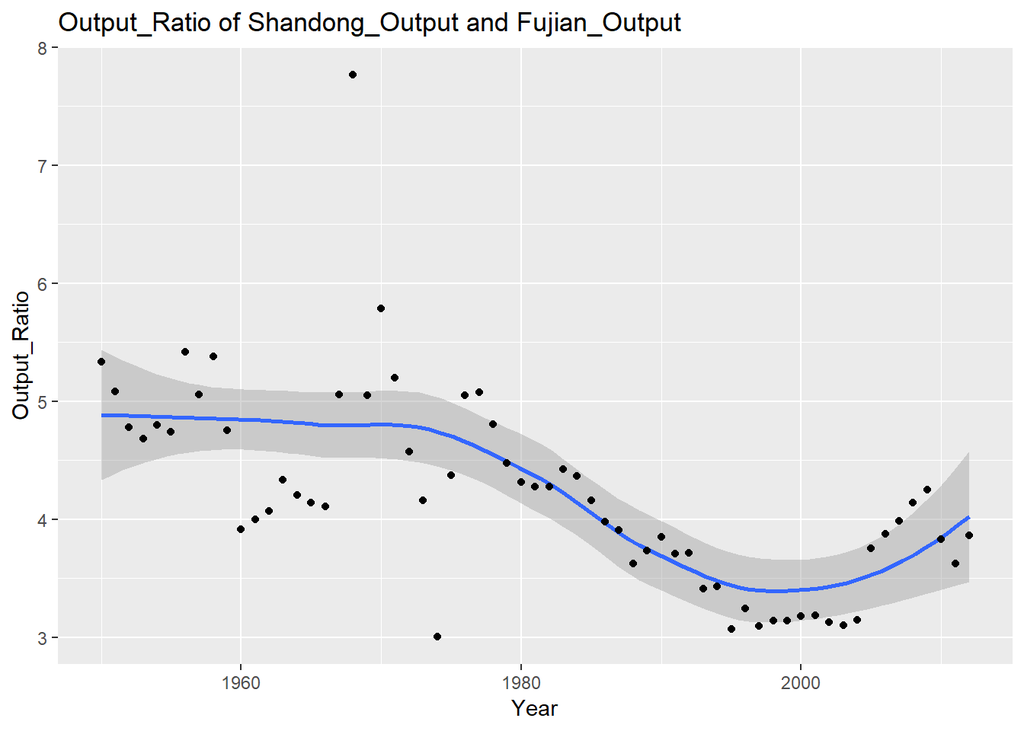

```
##    Year Guangdong_Output Liaoning_Output Output_Ratio
## 1  1949             9.89           11.90    0.8310924
## 2  1952            19.85           44.20    0.4490950
## 3  1957            37.92          117.10    0.3238258
## 4  1962            50.57          107.40    0.4708566
## 5  1965            71.76          170.50    0.4208798
## 6  1970           100.55          226.40    0.4441254
## 7  1975           155.23          319.16    0.4863705
## 8  1978           168.91          365.68    0.4619066
## 9  1979           181.96          388.52    0.4683414
## 10 1980           198.83          427.63    0.4649580
## 11 1981           226.26          427.18    0.5296596
## 12 1982           245.54          445.60    0.5510323
## 13 1983           275.25          494.00    0.5571862
## 14 1984           336.45          561.07    0.5996578
```

[output cut: 27 more lines]

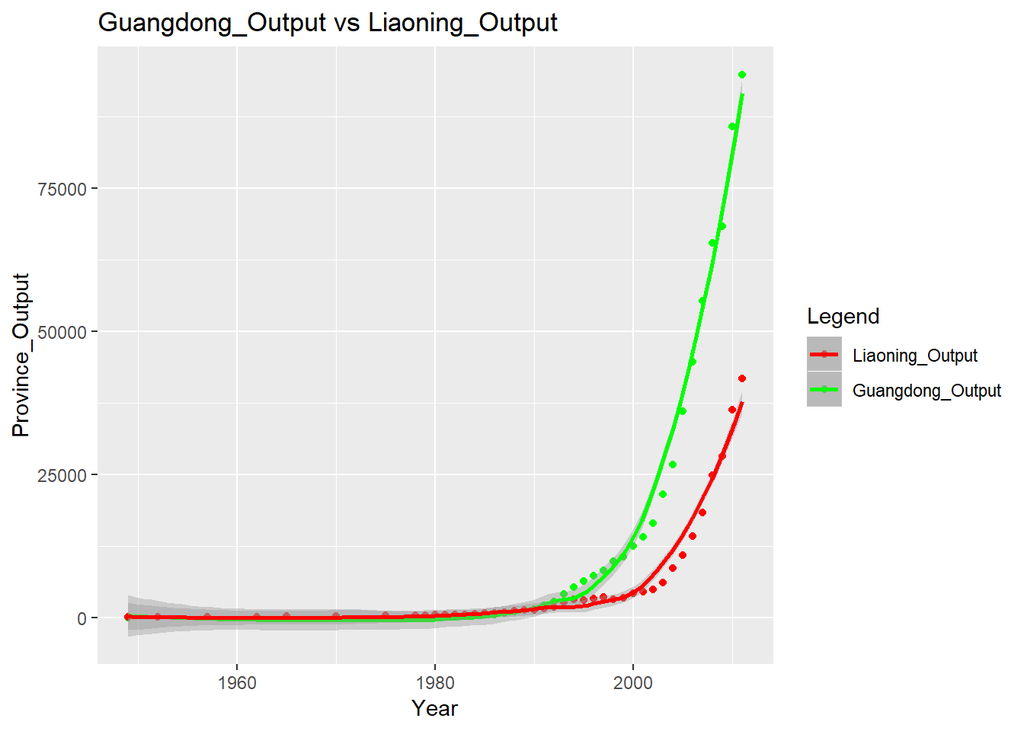

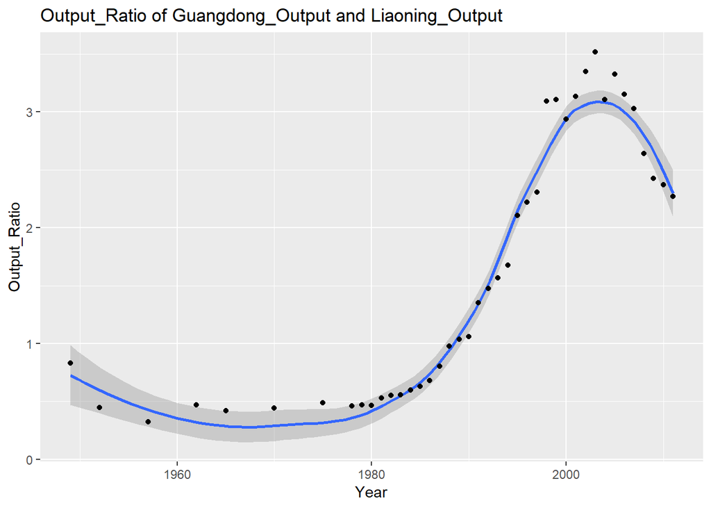

When it came to dealing with the NA values, I completely omitted them from the table. This is because those cells simply have no data to compare with which can skew data if left in.

# Part 3.2

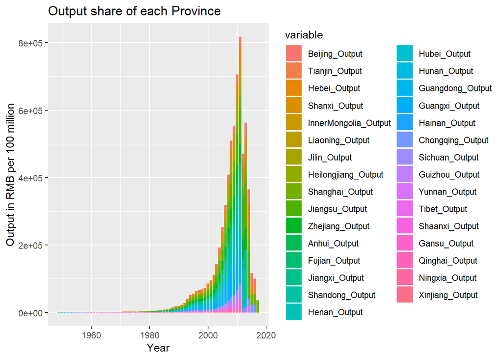

### Summary

Output of last 7 provinces in the legend decrease sharply after 2010 (most likely due to NA values). Growth increases in all regions until 2010.

# Part 3.3

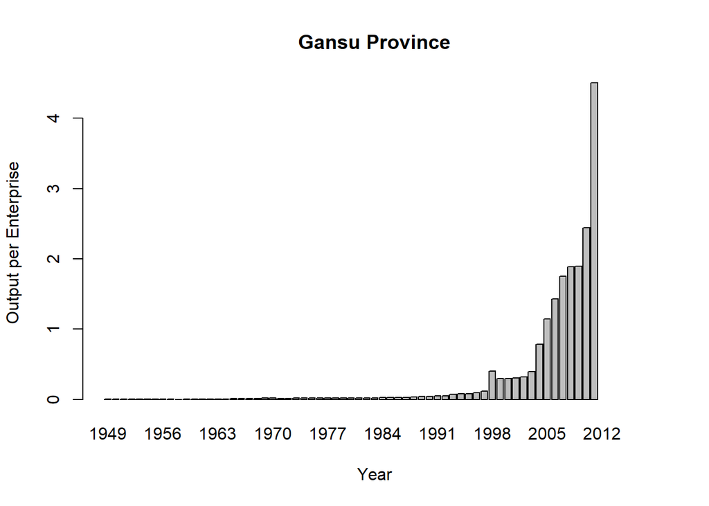

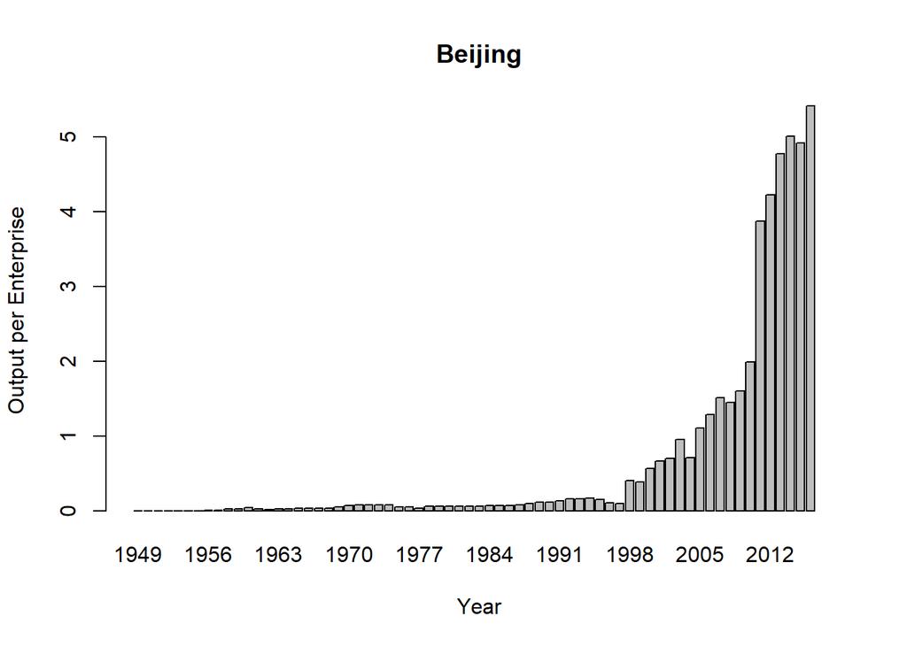

For Beijing, the monetary worth of Beijing’s enterprises increased from 1998 to 2007. From 2010 to 2012, we can see a sharp increase in this ratio up to 2017.

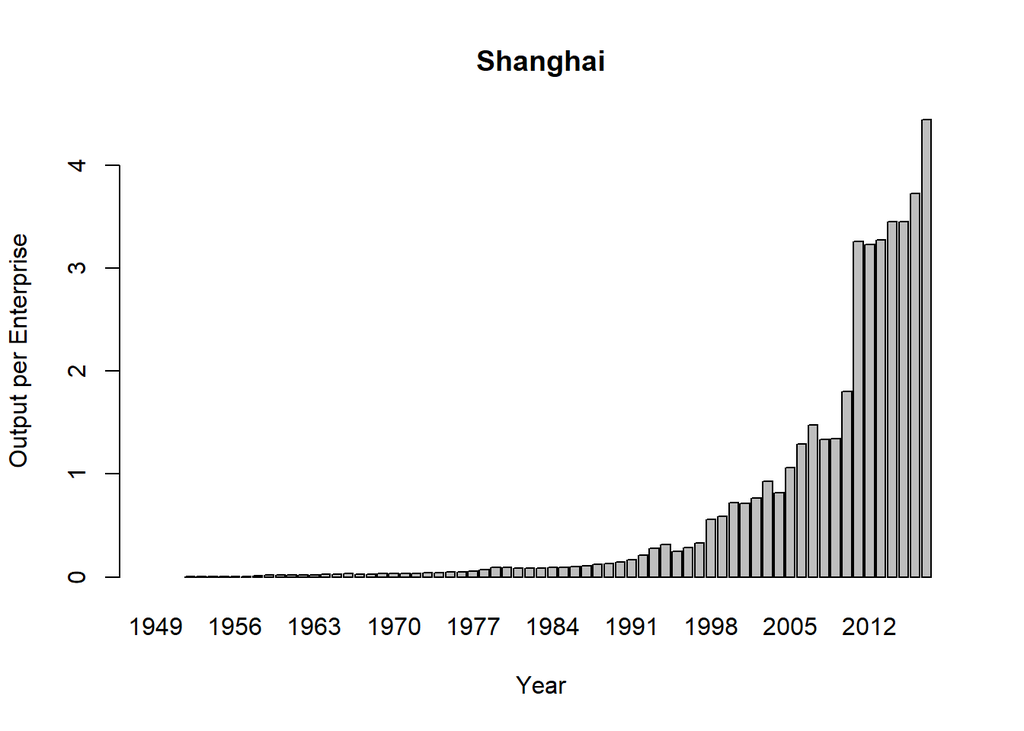

# Part 3.4

### Rename the column names

[figure not shown]

# Part 3.5

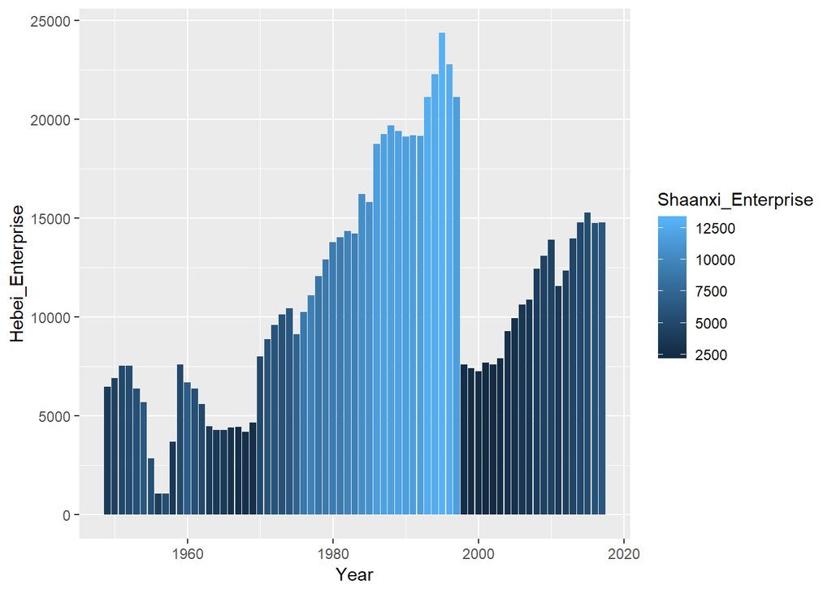

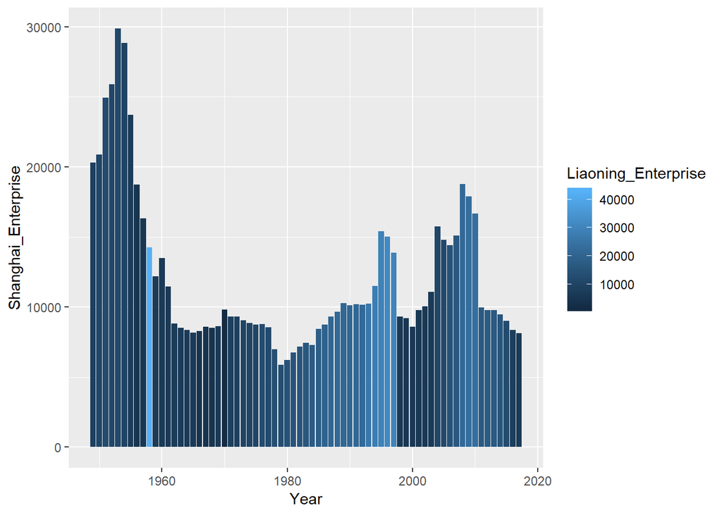

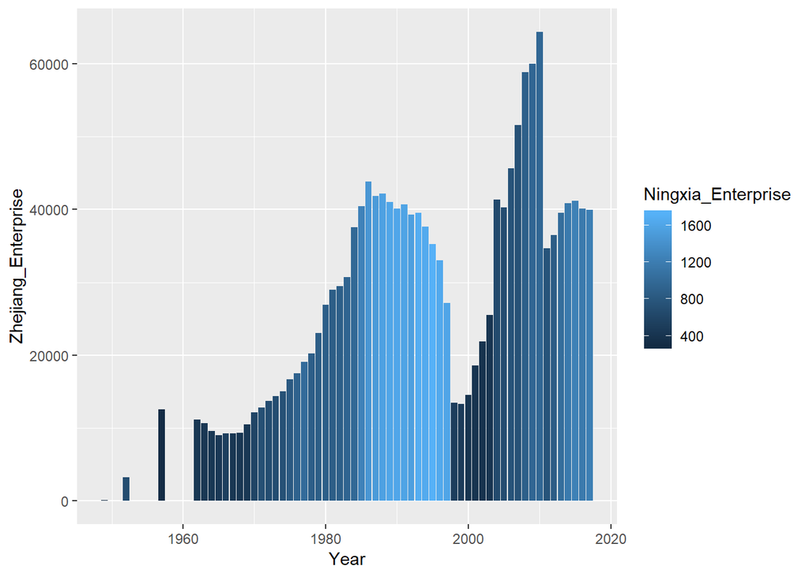

```
##   North_Ent North_Out NorthEast_Ent NorthEast_Out East_Ent East_Out
## 1   2251499   1046655       1939412        491122  8609878  3143361
##   SouthCentral_Ent SouthCentral_Out SouthWest_Ent SouthWest_Out
## 1          4956745          1215142       2400950        388217
##   NorthWest_Ent NorthWest_Out
## 1        965168      195497.8
```